# Lab-06

## Segment imagen using k-means clustering

We will employ sklearn Kmeans function to run the k-means clustering algorithm. After that, we will take the centroids color and use them to segment the image by replacing each pixel with the closest centroid color.

[figure not shown]

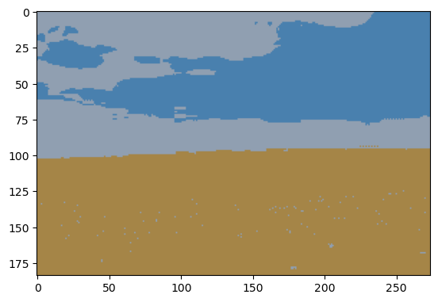

```python
import cv2
import numpy as np
import matplotlib.pyplot as plt
from sklearn.cluster import KMeans

def v3_distance(v1, v2):
    return np.sqrt(np.sum((v1 - v2)**2))
def filter_colors_k_means(n_clusters, img):
    clt = KMeans(n_clusters=n_clusters)
    clt.fit(img.reshape(-1,3))
    colors_to_map = clt.cluster_centers_

    for i in range(img.shape[0]):
        for j in range(img.shape[1]):
            pixel = img[i,j]
            lowest_distance = 999
            nearest_color = None
            for color in colors_to_map:
                distance = v3_distance(color, pixel)
                if distance < lowest_distance:
                    lowest_distance = distance
                    nearest_color = color
            img[i,j] = nearest_color
    return img

# read image
img_1 = cv2.imread('figura_1_BW.png', cv2.IMREAD_COLOR)
img_2 = cv2.imread('fieldWheat.png', cv2.IMREAD_COLOR)

# convert to RGB
img_1 = cv2.cvtColor(img_1, cv2.COLOR_BGR2RGB)
img_2 = cv2.cvtColor(img_2, cv2.COLOR_BGR2RGB)

# filter colors
img_1 = filter_colors_k_means(2, img_1)
img_2 = filter_colors_k_means(3, img_2)

# show image
plt.imshow(img_1)
plt.show()
plt.imshow(img_2)
plt.show()
```

## Image segmentation using Mean Shift

We will employ sklearn MeanShift function to run the Mean Shift algorithm. After that, we will take the centroids color and use them to segment the image by replacing each pixel with the closest centroid color.

[figure not shown]

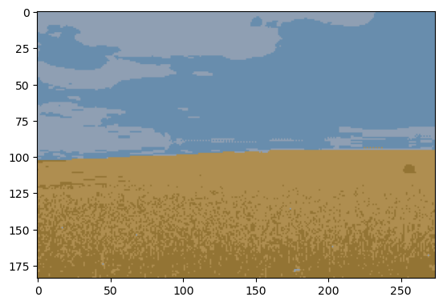

```python
from sklearn.cluster import MeanShift, estimate_bandwidth


def filter_colors_mean_shift(q, img):
    flat_image = img.reshape((-1,3))
    flat_image = np.float32(flat_image)

    bandwidth = estimate_bandwidth(flat_image, quantile=q, n_samples=100)
    ms = MeanShift(bandwidth=bandwidth, max_iter=10, bin_seeding=True)
    ms.fit(flat_image)
    labeled=ms.labels_

    colors_to_map = ms.cluster_centers_

    for i in range(img.shape[0]):
        for j in range(img.shape[1]):
            pixel = img[i,j]
            lowest_distance = 999
            nearest_color = None
            for color in colors_to_map:
                distance = v3_distance(color, pixel)
                if distance < lowest_distance:
                    lowest_distance = distance
                    nearest_color = color
            img[i,j] = nearest_color
    return img
#
#  read image
img_1 = cv2.imread('figura_1_BW.png', cv2.IMREAD_COLOR)
img_2 = cv2.imread('fieldWheat.png', cv2.IMREAD_COLOR)

# convert to RGB
img_1 = cv2.cvtColor(img_1, cv2.COLOR_BGR2RGB)
img_2 = cv2.cvtColor(img_2, cv2.COLOR_BGR2RGB)

# filter colors
img_1 = filter_colors_mean_shift(.5, img_1)
img_2 = filter_colors_mean_shift(.215, img_2)

# show image
plt.imshow(img_1)
plt.show()
plt.imshow(img_2)
plt.show()
```

## Lungs segmentation using Region Growing

We will employ a hand-crafted function of region growth to segment the lungs from the thresholded X-ray lungs image from practicum 05. The function will take the seed point,the color and a threshold as input and will return the segmented image.

The first approach for this exercise will come with hand-picked seeds.

```python
def region_growing(img, seed, threshold, color):
    img = img.copy()
    segmented = np.zeros(img.shape)
    black = np.array([0, 0, 0], dtype=np.float64)
    segmented[seed[0], seed[1]] = color
    current_region = [seed]
    while current_region:
        new_region = []
        for pixel in current_region:
            # fill region using neighbors
            for i in range(-1, 2):
                for j in range(-1, 2):
                    if pixel[0]+i >= 0 and pixel[0]+i < img.shape[0] and pixel[1]+j >= 0 and pixel[1]+j < img.shape[1]:
                        # if the pixel is not segmented and the difference between the pixel and the seed is less than the threshold
                        is_segmented = (segmented[pixel[0]+i, pixel[1]+j] == black).all()
                        is_similar = (v3_distance(img[pixel[0], pixel[1]], img[pixel[0]+i, pixel[1]+j]) < threshold).all()

                        if (is_segmented and is_similar):
                            segmented[pixel[0]+i, pixel[1]+j] = color
                            new_region.append([pixel[0]+i, pixel[1]+j])

        current_region = new_region
    return segmented

def multi_seed_region_growing(img, seeds, threshold, colors):
    if len(seeds)!=len(colors):
        print("Error: seeds and colors must have the same length")
        return
    segmented = np.zeros(img.shape, dtype=np.float64)
    for i in range(len(seeds)):
        segmented += region_growing(img, seeds[i], threshold, colors[i])
    return segmented
```

```
(1, 0, 0)
(0, 0, 1)
(0, 1, 0)
```

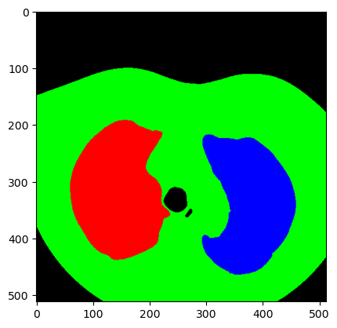

```python
# read lungs image
img = cv2.imread('lungs.png', cv2.IMREAD_COLOR)

# manual seeding process
seeds  = [[300, 100], [300, 400], [250,250]]
colors = [(1, 0, 0), (0, 0, 1), (0, 1, 0)]
segmented = multi_seed_region_growing(img, seeds, 0.5, colors)

# plot image
plt.imshow(segmented)
plt.show()
```

The second step of this exercise will be to compute the seeds automaticacally by parsing the image from left to right and setting a seed whenever the color changes.

```
(0.13725490196078433, 0.8509803921568627, 0.7843137254901961)
(0.36470588235294116, 0.5254901960784314, 0.6588235294117647)
(0.10196078431372549, 0.12549019607843137, 0.45098039215686275)
(0.01568627450980392, 0.9882352941176471, 0.788235294117647)
```

```
Clipping input data to the valid range for imshow with RGB data ([0..1] for floats or [0..255] for integers).
```

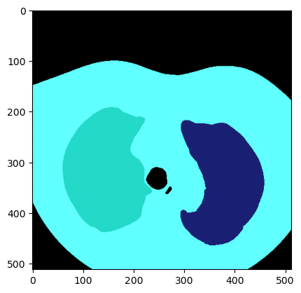

```python
import random
# automatic seeding process
# we will set a seed everytime the intensity difference of the pixel is greater than 100
# we will parse the image from left to right by its middle row by ten pixels each step
img = cv2.imread('lungs.png', cv2.IMREAD_COLOR)
seeds = []
colors = []
image_center_row = img.shape[0]//2

step = 5
# set image bkg as white
for i in range(step, img.shape[1]-step, step):
    px_i   = img[image_center_row, i]
    px_i_5 = img[image_center_row, i-step]

    if (v3_distance(px_i, px_i_5) > 1):
        seeds.append([image_center_row, i])
        colors.append((random.randrange(0, 255)/255, random.randrange(0, 255)/255, random.randrange(0, 255)/255))

segmented = multi_seed_region_growing(img, seeds, 0.5, colors)

plt.imshow(segmented)
plt.show()
```

As during the lungs thresholdization we managed to keep the center point separated we will move a little below the center point and set the seed there.

```
(0.08627450980392157, 0.8196078431372549, 0.8627450980392157)
(0.24313725490196078, 0.8, 0.8823529411764706)
(0.396078431372549, 0.45098039215686275, 0.5843137254901961)
(0.03529411764705882, 0.4980392156862745, 0.2549019607843137)
(0.40784313725490196, 0.2, 0.8235294117647058)
(0.16470588235294117, 0.2980392156862745, 0.6392156862745098)
```

```
Clipping input data to the valid range for imshow with RGB data ([0..1] for floats or [0..255] for integers).
```

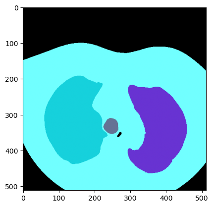

```python
img = cv2.imread('lungs.png', cv2.IMREAD_COLOR)
seeds = []
colors = []
image_center_row = 320

step = 5
# set image bkg as white
for i in range(step, img.shape[1]-step, step):
    px_i   = img[image_center_row, i]
    px_i_5 = img[image_center_row, i-step]

    if (v3_distance(px_i, px_i_5) > 1):
        seeds.append([image_center_row, i])
        colors.append((random.randrange(0, 255)/255, random.randrange(0, 255)/255, random.randrange(0, 255)/255))

segmented = multi_seed_region_growing(img, seeds, 0.5, colors)

plt.imshow(segmented)
plt.show()
```